# COVID-19 Pennsylvania Forecast Hub report 2021-01-05

Nicholas G Reich, Estee Y Cramer, Martha W Zorn, Evan L Ray, Serena Y Wang https://covid19forecasthub.org/

2021-01-05

# Background

This report provides a brief summary of the weekly ensemble forecast for Pennsylvania from the [COVID-19 Forecast Hub](https://covid19forecasthub.org/). In collaboration with the US CDC, our team aggregates COVID-19 forecasts from dozens of teams around the globe. Typically on Wednesday or Thursday of each week, a summary of the week’s forecasts from the COVID-19 Forecast Hub appear on the [official CDC COVID-19 forecasting page](https://www.cdc.gov/coronavirus/2019-ncov/covid-data/forecasting-us.html).

Every week, teams submit their forecasts to the COVID-19 Forecast Hub.

Each Tuesday, we combine the most recent forecasts from each team into a single “ensemble” forecast of reported COVID-19 cases at the county, state, and national level and deaths at the state and national level. At the moment, we only generate ensemble forecasts for four weeks into the future, as we don’t have reliable evidence that the models are accurate past that horizon.

Weekly reports from the COVID-19 Forecast Hub can be found at [this page](https://covid19forecasthub.org/doc/reports/). We expect that these reports will become more detailed as the weeks go on.

# COVID-19 Mortality Forecasts

Since the inputs to the ensemble model do not factor in changes in behavior or policy that could have an impact on short-term disease transmission (e.g. school openings or closures, new interventions, governmental policy shift, etc…), the ensemble model itself should not be looked to for specific answers to questions like “what will happen if or when schools open in 2 weeks” because most of the input models are not factoring in these changes. That said, the ensemble model has consistently shown strong predictive performance, and very few of the many interventions put in place appear to have created dramatic changes in short-term disease transmission.

## State level

This week, our ensemble combined forecasts for Pennsylvania from 46 different models.

At the state level, the ensemble model’s best guess is that we will see between 1,040 and 1,200 deaths each week for the next four weeks with around 21,000 deaths by January 30 (Figure 1). However for the week ending January 30, the ensemble shows substantial uncertainty, with observed deaths between 480 and 1,630 deemed possible (95% prediction interval: 481 - 1,626).

Throughought most of July, models have in general shown broad agreement about the trajectory of the outbreak over the coming weeks. However, the recent surge in cases has left models with quite different interpretations about what the next few weeks hold in terms of how many reported deaths from COVID-19 we will see. You can explore the full set of models, including their forecasts for past weeks online at our [interactive forecast visualization](https://viz.covid19forecasthub.org/).

Figure 1: Weekly observed and forecasted COVID-19 deaths. Observed data from [JHU CSSE](https://github.com/CSSEGISandData/COVID-19/tree/master/csse_covid_19_data/) and forecasts from the [COVID-19 Forecast Hub](https://covid19forecasthub.org/).

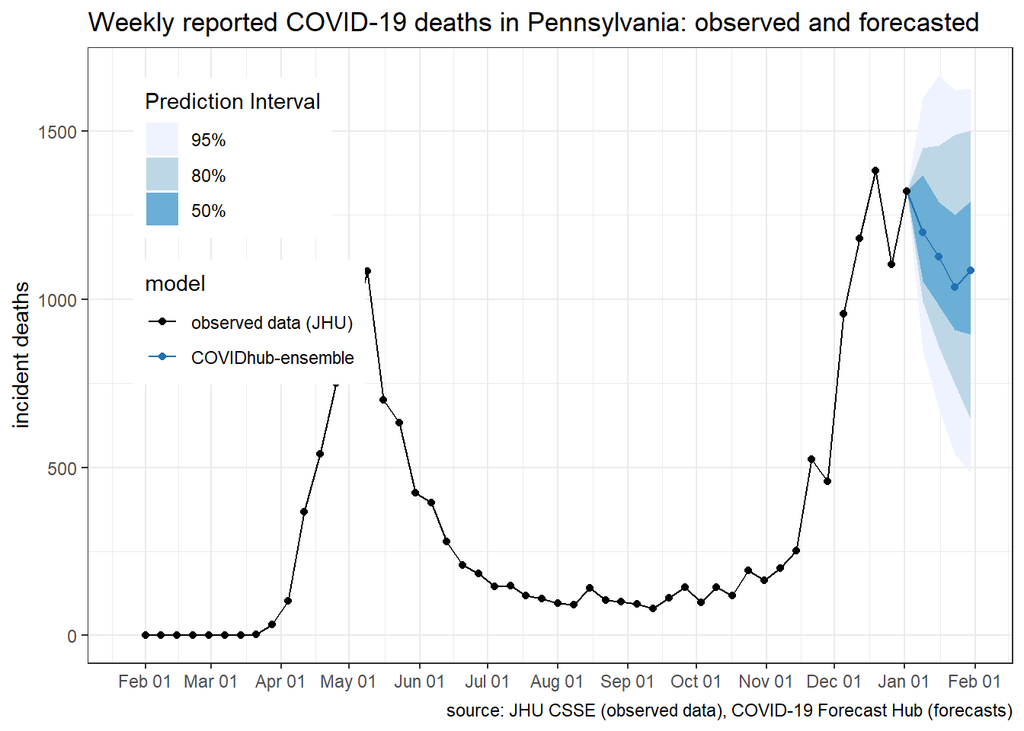

For state-level death forecasts made over the last 6 weeks in Pennsylvania for which observed data are now available, the 95% prediction intervals covered the truth 66% of the time, and the 50% prediction intervals covered the truth 22% of the time.

The sortable and searchable table below shows the total number of reported COVID-19 deaths at the US level and for Pennsylvania over the last two weeks (December 20, 2020 to January 02, 2021) and the forecasted counts for the subsequent two weeks (January 03, 2021 to January 16, 2021).

[interactive table not shown]

# COVID-19 Incident Case Forecasts

## State level

At the state level, the ensemble model’s best guess is that we will see between 40,500 and 50,300 cases each week for the next four weeks (Figure 2). However for the week ending January 30, the ensemble shows substantial uncertainty, with observed cases between 18,500 and 74,626.

You can explore the full set of models, including their forecasts for past weeks online at our [interactive forecast visualization](https://viz.covid19forecasthub.org/).

Figure 2: Weekly observed and forecasted COVID-19 Cases. Observed data from [JHU CSSE](https://github.com/CSSEGISandData/COVID-19/tree/master/csse_covid_19_data/) and forecasts from the [COVID-19 Forecast Hub](https://covid19forecasthub.org/).

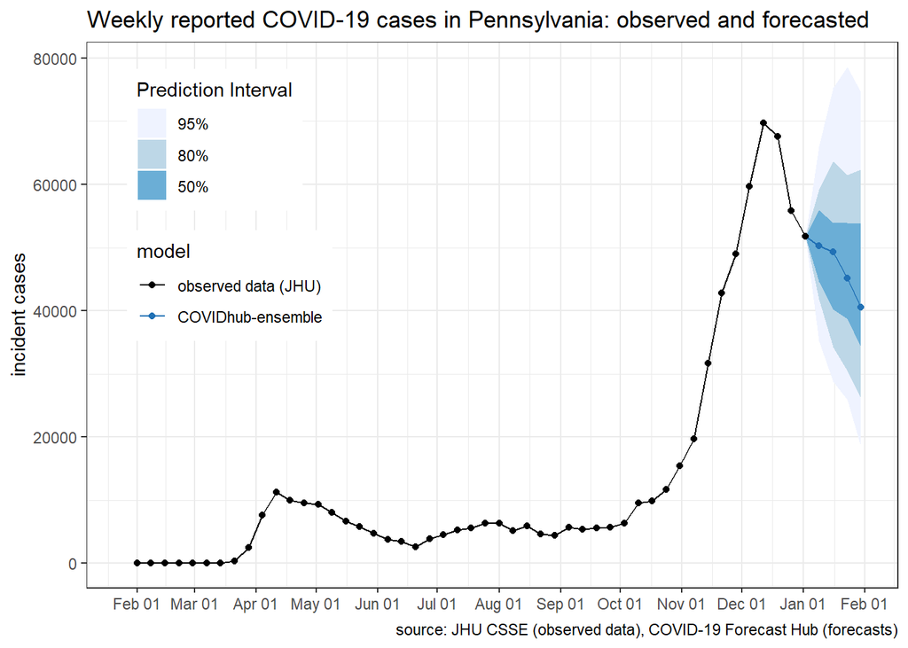

For state-level case forecasts made over the last 6 weeks in Pennsylvania for which observed data are now available, the 95% prediction intervals covered the truth 88% of the time, and the 50% prediction intervals covered the truth 33% of the time. The truth tended to be lower than the prediction interval.

The sortable and searchable table below shows the total number of reported COVID-19 cases at the US and state level for Pennsylvania as of Saturday, January 02, 2021 (“Total COVID-19 Cases”), as well as the weekly case count and rate of reported COVID-19 cases in the population (standardized per 100,000 population) over the last week (December 27, 2020 to January 02, 2021) and two weeks ahead (January 10, 2021 to January 16, 2021).

When interpreting probability of an increase, it’s important to note that the increase or decrease is relative to the location-specific recent observed incidence, which varies across locations.

[interactive table not shown]

## County level

The sortable and searchable table below shows the total number of reported COVID-19 cases at the county level for Pennsylvania as of Saturday,January 02, 2021 (“Total COVID-19 Cases”) as well as the rate of reported COVID-19 cases in the population (standardized per 100,000 population) over the last two weeks and over the next two weeks.

For county-level case forecasts made over the last 6 weeks in Pennsylvania for which observed data are now available, the 95% prediction intervals covered the truth 90% of the time and the 50% prediction intervals covered the truth 44% of the time. The truth tended to be higher than the prediction interval.

Looking at the rates allows for easier comparison across counties, where you can see which counties have had or are predicted to have propoportionally higher rates in comparison to other counties. These tables calculate the weekly case count and rate of reported COVID-19 cases in the population (standardized per 100,000 population) over the last week(December 27, 2020 to January 02, 2021) and two weeks ahead (January 10, 2021 to January 16, 2021).

When interpreting probability of an increase, it’s important to note that the increase or decrease is relative to the location-specific recent observed incidence, which varies across locations.

[interactive table not shown]

Select a County

[interactive chart not shown]

This report was reproducibly and dynamically generated using RMarkdown. The code for the report can be found [here](https://github.com/reichlab/covid19-forecast-hub/tree/master/code/reports).